# ¶ FINAL EXAMINATION ¶

#### INSTRUCTIONS:

- Type each one of the R commands in this lesson on the space provided below.
- You can embed an R code chunk like this:

  ```r
  summary(cars)
  ```

  ```
  ##      speed           dist
  ##  Min.   : 4.0   Min.   :  2.00
  ##  1st Qu.:12.0   1st Qu.: 26.00
  ##  Median :15.0   Median : 36.00
  ##  Mean   :15.4   Mean   : 42.98
  ##  3rd Qu.:19.0   3rd Qu.: 56.00
  ##  Max.   :25.0   Max.   :120.00
  ```

- Before you move to the next step, highlight or move the cursor to the end of the individual R command and click on **Run**. Do this for all R commands.
- After you are done click the **Knit HTML**, **Knit PDF** button (upper left window). A document will be generated that includes both content as well as the output of any embedded R code chunks within the document.
- Go to File –> Save. Name your file.
- Upload the file to the Canvas site by using the link provided.

##### Problem 1. (16 points)

The data set at [http://mnstats.morris.umn.edu/Data/rnf6080.dat] records hourly rainfall at a certain location in Canada, every day from 1960 to 1980. The file is also given through the link labeled `Data file Final Exam (rnf6080.dat)`.

1. First, we need to load the data set into R using the command `read.table()`. Use the help function to learn what arguments this function takes. Once you have the necessary input, load the data set into R and make it a data frame called `rain.df`.

##### Solution

Type your answer here

```r
rain.df = read.table("rnf6080.dat")
```

2. How many rows and columns does `rain.df` have? (If there are not 5070 rows and 27 columns, something is wrong; check the previous part to see what might have gone wrong in the previous part.)

##### Solution

Type your answer here

```r
nrow(rain.df)
```

```
## [1] 5070
```

```r
ncol(rain.df)
```

```
## [1] 27
```

3. What are the names of the columns of `rain.df`? (note: It’s okay if the names aren’t yet informative)

##### Solution

Type your answer here

```r
colnames(rain.df)
```

```
##  [1] "V1"  "V2"  "V3"  "V4"  "V5"  "V6"  "V7"  "V8"  "V9"  "V10" "V11" "V12"
## [13] "V13" "V14" "V15" "V16" "V17" "V18" "V19" "V20" "V21" "V22" "V23" "V24"
## [25] "V25" "V26" "V27"
```

4. What is the value of row 5, column 7 of `rain.df`?

##### Solution

Type your answer here

```r
rain.df[5, 7]
```

```
## [1] 0
```

5. Display the second row of `rain.df` in its entirety.

##### Solution

Type your answer here

```r
rain.df[2,]
```

```
##   V1 V2 V3 V4 V5 V6 V7 V8 V9 V10 V11 V12 V13 V14 V15 V16 V17 V18 V19 V20 V21
## 2 60  4  2  0  0  0  0  0  0   0   0   0   0   0   0   0   0   0   0   0   0
##   V22 V23 V24 V25 V26 V27
## 2   0   0   0   0   0   0
```

6. Make the code chunk below executable and explain what this command does

```r
names(rain.df) <- c("year","month","day",seq(0,23))
#this code chunk renames the columns of rain.df to year, month, day, and then the rest of the columns will be named 0 to 23
colnames(rain.df)
```

```
##  [1] "year"  "month" "day"   "0"     "1"     "2"     "3"     "4"     "5"
## [10] "6"     "7"     "8"     "9"     "10"    "11"    "12"    "13"    "14"
## [19] "15"    "16"    "17"    "18"    "19"    "20"    "21"    "22"    "23"
```

by running it on your data and examining the object. (You may find the display functions `head()` and `tail()` useful here.) Is it clear now what the last 24 columns represent?

##### Solution

Type your answer here

```r
head(rain.df)
```

```
##   year month day 0 1 2 3 4 5 6 7 8 9 10 11 12 13 14 15 16 17 18 19 20 21 22 23
## 1   60     4   1 0 0 0 0 0 0 0 0 0 0  0  0  0  0  0  0  0  0  0  0  0  0  0  0
## 2   60     4   2 0 0 0 0 0 0 0 0 0 0  0  0  0  0  0  0  0  0  0  0  0  0  0  0
## 3   60     4   3 0 0 0 0 0 0 0 0 0 0  0  0  0  0  0  0  0  0  0  0  0  0  0  0
## 4   60     4   4 0 0 0 0 0 0 0 0 0 0  0  0  0  0  0  0  0  0  0  0  0  0  0  0
## 5   60     4   5 0 0 0 0 0 0 0 0 0 0  0  0  0  0  0  0  0  0  0  0  0  0  0  0
## 6   60     4   6 0 0 0 0 0 0 0 0 0 0  0  0  0  0  0  0  0  0  0  0  0  0  0  0
```

```r
tail(rain.df)
```

```
##      year month day 0 1 2 3 4 5 6 7 8 9 10 11 12 13 14 15 16 17 18 19 20 21 22
## 5065   80    11  25 0 0 0 0 0 0 0 0 0 0  0  0  0  0  0  0  0  0  0  0  0  0  0
## 5066   80    11  26 0 0 0 0 0 0 0 0 0 0  0  0  0  0  0  0  0  0  0  0  0  0  0
## 5067   80    11  27 0 0 0 0 0 0 0 0 0 0  0  0  0  0  0  0  0  0  0  0  0  0  0
## 5068   80    11  28 0 0 0 0 0 0 0 0 0 0  0  0  0  0  0  0  0  0  0  0  0  0  0
## 5069   80    11  29 0 0 0 0 0 0 0 0 0 0  0  0  0  0  0  0  0  0  0  0  0  0  0
## 5070   80    11  30 0 0 0 0 0 0 0 0 0 0  0  0  0  0  0  0  0  0  0  0  0  0  0
##      23
## 5065  0
## 5066  0
## 5067  0
## 5068  0
## 5069  0
## 5070  0
```

```r
#the last 24 columns most likely represents amount of rainfall in each hour of each day.
```

7. Create a new column in the data frame called `daily`, which is the sum of the rightmost 24 columns. With this column, create a histogram of the values in this column, which are supposed to be daily rainfall values. What is wrong with this picture? Be thorough.

##### Solution

Type your answer here

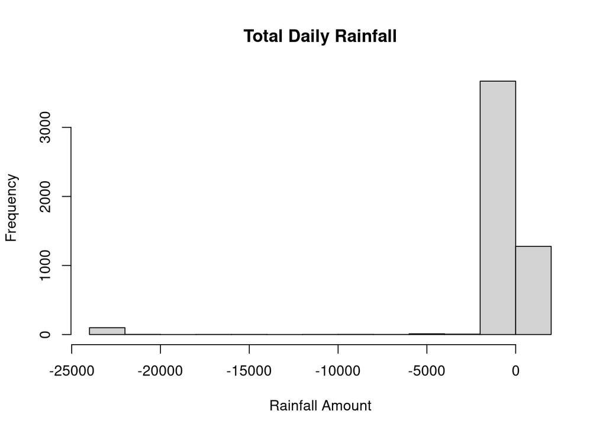

```r
rain.df$daily = rowSums(rain.df[,4:27])
hist(rain.df$daily, main = "Total Daily Rainfall", xlab = "Rainfall Amount", ylab = "Frequency")
```

```r
#the x axis should be amounts of rainfall but the data goes negative. it looks like the data is skewed by some rainfall amounts that are -25000.
min(rain.df$daily)
```

```
## [1] -23976
```

```r
#the min of -23976 is throwing off the rest of the data
```

8. Create a new data frame `rain.df.fixed` that takes the original and fixes it for any flaws you have discovered. Explain your fix and the reasoning behind it. Having done this, produce a new histogram with the corrected data and explain why this is more reasonable.

##### Solution

Type your answer here

```r
rain.df.negatives = apply(rain.df, 1, function(x) any(x < 0))
rain.df.fixed = rain.df[!rain.df.negatives, ]
min(rain.df.fixed$daily)
```

```
## [1] 0
```

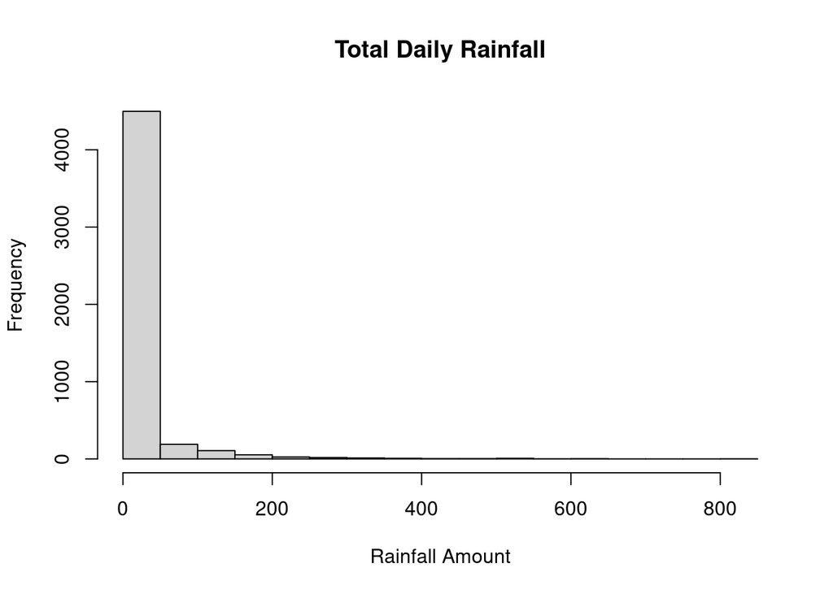

```r
hist(rain.df.fixed$daily, main = "Total Daily Rainfall", xlab = "Rainfall Amount", ylab = "Frequency")
```

```r
#the fix i did was to identify values in rain.df that were negative, and then create a new data frame (rain.df.fixed) that was just the original data frame without those negative values.
```

##### Problem 2. (4 points)

Syntax and class-typing.

1. For each of the following commands, if the command executes without generating an error either explain why it *should* be an error, or explain the meaning behind the observed result. If the command **does** explicitly generate an error, explain why.

```
vector1 <- c("5", "12", "7", "32")
max(vector1)
sort(vector1)
sum(vector1)
```

##### Solution

Type your answer here

```r
vector1 <- c(5, 12, 7, 32)
max(vector1)
```

```
## [1] 32
```

```r
sort(vector1)
```

```
## [1]  5  7 12 32
```

```r
sum(vector1)
```

```
## [1] 56
```

```r
#the error was that the elements being put in the vector were strings and not numbers. the fix was to change the elements into numbers.
```

2. Similar to part a, for the next series of commands (which are naturally divided into 3 sets), either explain their results, or why they should produce errors. Be sure to compare and contrast between them.

```
vector2 <- c("5",7,12)
vector2[2] + vector2[3]

dataframe3 <- data.frame(z1="5",z2=7,z3=12)
dataframe3[1,2] + dataframe3[1,3]

list4 <- list(z1="6", z2=42, z3="49", z4=126)
list4[[2]]+list4[[4]]
list4[2]+list4[4]
```

##### Solution

Type your answer here

```r
#vector2 <- c("5",7,12)
#vector2[2] + vector2[3]
#this code does not work because the first element is a string. so R will read all elements as characters

dataframe3 <- data.frame(z1="5",z2=7,z3=12)
dataframe3[1,2] + dataframe3[1,3]
```

```
## [1] 19
```

```r
#this code does work because its creating a data frame and not a vector. R will keep elements as characters or numbers in a dataframe.

list4 <- list(z1="6", z2=42, z3="49", z4=126)
list4[[2]]+list4[[4]]
```

```
## [1] 168
```

```r
#list4[2]+list4[4]
#the first addition works because list[[2]] and list[[4]] with double brackets gets the elements themselves from the list where list[2] and list[4] with single brackets are getting the elements as sublist and R cannot add them together.
```

##### Problem 3. (4 points)

Working with functions and operators.

1. The colon operator will create a sequence of integers in order. It is a special case of the function `seq()`. Using the help command `?seq` to learn about the function, design an expression that will give you the sequence of numbers from 1 to 10000 in increments of 372. Design another that will give you a sequence between 1 and 10000 that is exactly 50 numbers in length.

##### Solution

Type your answer here

```r
seq(from = 1, to = 10000, by = 372)
```

```
##  [1]    1  373  745 1117 1489 1861 2233 2605 2977 3349 3721 4093 4465 4837 5209
## [16] 5581 5953 6325 6697 7069 7441 7813 8185 8557 8929 9301 9673
```

```r
seq(from = 1, to = 10000, length.out = 50)
```

```
##  [1]     1.0000   205.0612   409.1224   613.1837   817.2449  1021.3061
##  [7]  1225.3673  1429.4286  1633.4898  1837.5510  2041.6122  2245.6735
## [13]  2449.7347  2653.7959  2857.8571  3061.9184  3265.9796  3470.0408
## [19]  3674.1020  3878.1633  4082.2245  4286.2857  4490.3469  4694.4082
## [25]  4898.4694  5102.5306  5306.5918  5510.6531  5714.7143  5918.7755
## [31]  6122.8367  6326.8980  6530.9592  6735.0204  6939.0816  7143.1429
## [37]  7347.2041  7551.2653  7755.3265  7959.3878  8163.4490  8367.5102
## [43]  8571.5714  8775.6327  8979.6939  9183.7551  9387.8163  9591.8776
## [49]  9795.9388 10000.0000
```

2. The function `rep()` repeats a vector some number of times. Explain the difference between `rep(1:3, times=3) and rep(1:3, each=3).

##### Solution

Type your answer here

```r
rep(1:3, times=3)
```

```
## [1] 1 2 3 1 2 3 1 2 3
```

```r
#this repeats the sequence 1 2 3 three times in that order
rep(1:3, each=3)
```

```
## [1] 1 1 1 2 2 2 3 3 3
```

```r
#this repeats each number in the sequence three times in order
```

##### Problem 4. (18 points)

The data set at [http://mnstats.morris.umn.edu/Data/calif_penn_2011.csv] contains information about the housing stock of California and Pennsylvania, as of 2011. Information as aggregated into “Census tracts”, geographic regions of a few thousand people which are supposed to be fairly homogeneous economically and socially. The file is also given through the link labeled `Data file Final Exam (calif_penn_2011.csv)`.

1. Load the data into a dataframe called `ca_pa`.

##### Solution

Type your answer here

```r
ca_pa = read.csv("calif_penn_2011.csv")
```

2. How many rows and columns does the dataframe have?

##### Solution

Type your answer here

```r
nrow(ca_pa)
```

```
## [1] 11275
```

```r
ncol(ca_pa)
```

```
## [1] 34
```

3. Run this command, and explain, in words, what this does:

```
colSums(apply(ca_pa,c(1,2),is.na))
"this code sums up the number of na's in each column."
```

##### Solution

Type your answer here

```r
colSums(apply(ca_pa,c(1,2),is.na))
```

```
##                           X                     GEO.id2
##                           0                           0
##                     STATEFP                    COUNTYFP
##                           0                           0
##                     TRACTCE                  POPULATION
##                           0                           0
##                    LATITUDE                   LONGITUDE
##                           0                           0
##           GEO.display.label          Median_house_value
##                           0                         599
##                 Total_units                Vacant_units
##                           0                           0
##                Median_rooms  Mean_household_size_owners
##                         157                         215
## Mean_household_size_renters         Built_2005_or_later
##                         152                          98
##          Built_2000_to_2004                 Built_1990s
##                          98                          98
##                 Built_1980s                 Built_1970s
##                          98                          98
##                 Built_1960s                 Built_1950s
##                          98                          98
##                 Built_1940s       Built_1939_or_earlier
##                          98                          98
##                  Bedrooms_0                  Bedrooms_1
##                          98                          98
##                  Bedrooms_2                  Bedrooms_3
##                          98                          98
##                  Bedrooms_4          Bedrooms_5_or_more
##                          98                          98
##                      Owners                     Renters
##                         100                         100
##     Median_household_income       Mean_household_income
##                         115                         126
```

```r
"this code sums up the number of na's in each column."
```

```
## [1] "this code sums up the number of na's in each column."
```

4. The function `na.omit()` takes a dataframe and returns a new dataframe, omitting any row containing an NA value. Use it to purge the data set of rows with incomplete data.

##### Solution

Type your answer here

```r
na.omit(ca_pa)
```

```
##         X    GEO.id2 STATEFP COUNTYFP TRACTCE POPULATION LATITUDE LONGITUDE
## 2       2 6001400200       6        1  400200       1974 37.84829 -122.2495
## 3       3 6001400300       6        1  400300       4865 37.84027 -122.2544
## 4       4 6001400400       6        1  400400       3703 37.84845 -122.2573
## 5       5 6001400500       6        1  400500       3517 37.84894 -122.2647
## 6       6 6001400600       6        1  400600       1571 37.84223 -122.2649
## 7       7 6001400700       6        1  400700       4206 37.84172 -122.2721
## 8       8 6001400800       6        1  400800       3594 37.84539 -122.2831
## 9       9 6001400900       6        1  400900       2302 37.83928 -122.2803
## 10     10 6001401000       6        1  401000       5678 37.83126 -122.2722
## 11     11 6001401100       6        1  401100       4156 37.82996 -122.2634
## 12     12 6001401200       6        1  401200       2416 37.83099 -122.2580
## 13     13 6001401300       6        1  401300       3528 37.81650 -122.2679
## 14     14 6001401400       6        1  401400       4314 37.81990 -122.2733
## 15     15 6001401500       6        1  401500       2630 37.82350 -122.2805
```

[output cut: 23522 more lines]

5. How many rows did this eliminate?

##### Solution

Type your answer here

```r
nrow(ca_pa) - nrow(na.omit(ca_pa))
```

```
## [1] 670
```

```r
#670 rows were eliminated
```

6. Are your answers in (c) and (e) compatible? Explain.

##### Solution

Type your answer here

```r
#no, part c, and e are not compatible. part c sums up the total number of na's in each column while e is telling us how much rows had at least 1 na in them. these two numbers arent compatible because a row might have had multiple na's in different columns
```

The column `COUNTYFP` contains a numerical code for counties within each state. We are interested in Alameda County (county 1 in California), Santa Clara (county 85 in California), and Allegheny County (county 3 in Pennsylvania).

7. Explain what the block of code below is supposed to accomplish, and how it does it.

```r
acca <- c()
for (tract in 1:nrow(ca_pa)) {
  if (ca_pa$STATEFP[tract] == 6) {
    if (ca_pa$COUNTYFP[tract] == 1) {
      acca <- c(acca, tract)
    }
  }
}

accamhv <- c()
for (tract in acca) {
  accamhv <- c(accamhv, ca_pa[tract,10])
}
median(accamhv)
```

```
## [1] NA
```

##### Solution

Type your answer here

```r
#the first bit of code is going through the STATEFP and COUNTYFP columns and checking if thier values are 6 and 1. if both of those are true that index is added to the acca vector. the second bit of code goes through acca and gets the value of the 10th column of that row and adds it to the accamhv vector. the last bit of code then gets the median of accahv vector
```

8. Give a single line of R which gives the same final answer as the block of code. Note: there are at least two ways to do this; you just have to find one.

##### Solution

Type your answer here

```r
colnames(ca_pa[10])
```

```
## [1] "Median_house_value"
```

```r
#10th column is "Median_house_value"
median(ca_pa$Median_house_value[ca_pa$STATEFP == 6 & ca_pa$COUNTYFP == 1], na.rm = TRUE)
```

```
## [1] 473500
```

```r
median(accamhv, na.rm = TRUE)
```

```
## [1] 473500
```

```r
#both methods come to the same result
```

1. For Alameda, Santa Clara and Allegheny Counties, what were the average percentages of housing built since 2005?

##### Solution

Type your answer here

```r
(sum(ca_pa$Built_2005_or_later[ca_pa$COUNTYFP == 1], na.rm = TRUE)/sum(ca_pa[ca_pa$COUNTYFP == 1, 16:24], na.rm = TRUE))*100
```

```
## [1] 3.125179
```

```r
#approximately 3.125% of houses were built since 2005 in Alameda county

(sum(ca_pa$Built_2005_or_later[ca_pa$COUNTYFP == 85], na.rm = TRUE)/sum(ca_pa[ca_pa$COUNTYFP == 85, 16:24], na.rm = TRUE))*100
```

```
## [1] 3.054138
```

```r
#approximately 3.054% of houses were built since 2005 in Santa Clara county

(sum(ca_pa$Built_2005_or_later[ca_pa$COUNTYFP == 3], na.rm = TRUE)/sum(ca_pa[ca_pa$COUNTYFP == 3, 16:24], na.rm = TRUE))*100
```

```
## [1] 1.883868
```

```r
#approximately 1.88% of houses were built since 2005 in Allegheny county
```

##### Problem 5. (4 points)

Write a function that takes as its argument two vectors, $x$ and $y$, produces a scatterplot, and calculates the correlation coefficient (using `cor(x,y)`) and test it on any two variables given in the `calif_penn_2011.csv`.

##### Solution

Type your answer here

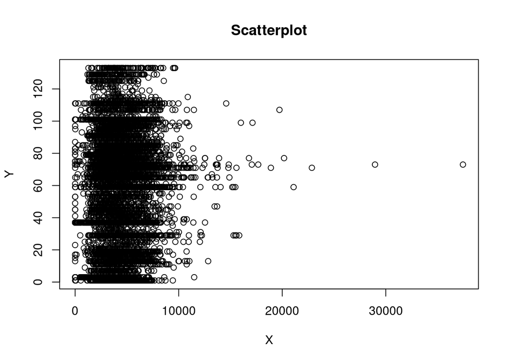

```
## [1] 0.06417337
```

```r
correlate.coefficient = function(x, y) {
  plot(x, y, main = "Scatterplot", xlab = "X", ylab = "Y")
  cor(x, y)
  }
correlate.coefficient(ca_pa$POPULATION, ca_pa$COUNTYFP)
```

##### Problem 6. (8 points)

For this problem we will use the built-in ‘barley’ data frame in the ‘lattice’ library. So first load the library.

```r
#install.packages("lattice")
library(lattice)
```

Explain what the following functions does a. `lapply (barley, function(x) length(unique(x)))`

##### Solution

Type your answer here

```r
#the code is applying the function length(unique(x)) to each element in the data "barley". the length(unique(x)) function tells us the number of unique values in each column of "barley". lapply means that the result will be in a list form.
```

2. `sapply (barley, function(x) length(unique(x)))`

##### Solution

Type your answer here

```r
#this code does pretty much the same thing as part a but this time its using sapply. it will return the results as a matrix
```

3. `tapply (barley$yield, barley$site, mean)`

##### Solution

Type your answer here

```r
#this code we are applying the mean function for the subsets of data coming from barley. we are finding the mean yield for each site. the tapply function is being used because we want to apply the mean function to the subset barley$yield
```

4. `tapply (barley$yield, list (barley$year, barley$site), mean)`

##### Solution

Type your answer here

```r
#this code is doing a similar thing as part c. but this time yield is being grouped into two factors, year and site. so the code is finding the mean yield from the different sites and different years
```

##### Problem 7. (10 points)

First let us create a matrix ‘a’.

```r
a <- matrix (c(5, 2, 7, 1, 2, 8, 4, 5, 6), 3, 3)
```

Explain what each one of the functions does.

1. `apply (a, 1, min)`

##### Solution

Type your answer here

```r
#this code is applying the min function each row of the matrix. it would return the min of the first row, then second, then third.
```

2. `which (c(F, F, T, F, T, T, F))`

##### Solution

Type your answer here

```r
#this code is finding the index positions of the T's. it would return 3 5 6 because those are the positions that the T's are in.
```

3. `apply (a, 1, function(x) which(x == min(x)))`

##### Solution

Type your answer here

```r
#this code is applying the function which(x == min(x)) to each row of the matrix a. its finding the index position of the min value in each row. for row 1 it returns 2, for row 2 it returns 1 and 2 because the min value shows up twice, and for row three it returns 3
```

4. `apply (a, 1, function(x) which(x == min(x))[1])`

##### Solution

Type your answer here

```r
#this code does pretty much the same thing as c but the [1] at the end means that its going to return only the first element of each result. so it will return 2 1 3.
```

5. Use the `apply()` function to find the sum of each row.

##### Solution

Type your answer here

```r
apply (a, 1, sum)
```

```
## [1] 10  9 21
```

6. Use the `apply()` function to find the sum of each column

##### Solution

Type your answer here

```r
apply (a, 2, sum)
```

```
## [1] 14 11 15
```

##### Problem 8. (4 points)

Loops are a last resort, not a first. So answer the following questions

1. Explain what the following commands does

```
foo = seq(1, 100, by=2)

foo.squared = NULL

for (i in 1:50 ) {
  foo.squared[i] = foo[i]^2
}
```

##### Solution

Type your answer here

```r
#this code creates a vector of a sequence of numbers 1 to 100 counting by 2. then an empty vector is created called foo.squared. it then loops through index position 1 to 50 and it squares that same index position in the foo vector, squares is, and stores it in foo.squared. so foo.squared will contain the square values of foo.
```

2. What is a better way of doing what the loop in a does by using vectorizing capability of R?

##### Solution

Type your answer here

```r
foo = seq(1, 100, by=2)
foo.squared = foo^2
foo.squared
```

```
##  [1]    1    9   25   49   81  121  169  225  289  361  441  529  625  729  841
## [16]  961 1089 1225 1369 1521 1681 1849 2025 2209 2401 2601 2809 3025 3249 3481
## [31] 3721 3969 4225 4489 4761 5041 5329 5625 5929 6241 6561 6889 7225 7569 7921
## [46] 8281 8649 9025 9409 9801
```

.

##### Total Number of Points Earned: XX/70